# PROJECTE ANÀLISI DE DADES: Wine Quality

David Anglada Rotger i Andreu Huguet Segarra

17/5/2019

# Introducció

Avui en dia, el rang de consumidors del vi s’ha amplitat moltíssims, convertint-se amb una beguda que es pot trobar a totes les cases i, fins i tot, comparable amb la cervesa. Això ha provocat que l’interés per aquest producte hagi augmentat els darrers anys, provocant també un creixement de la indústria de la vineria. Com a conseqüència, el nombre d’investigacions i estudis que tenen com a finalitat la millora de la qualitat del vi o la pujada de les seves vendes s’ha disparat.

Un dels temes que preocupa més a aquest sector és la **certificació de qualitat**, un aspecte que depèn profundament de la catació i valoració d’enòlegs experts. Així doncs, la finalitat d’aquest estudi és estudiar quines variables afecten més a la qualitat final del vi i de quina manera influeixen.

Donat que algunes d’aquestes variables es poden controlar durant el procés de producció, serà interessant veure les que influeixen possitivament amb l’objectiu de potenciar-les, o detectar les que influeixen negativament per poder intentar neutralitzar el seu efecte.

# Descripció de la Base de Dades

Per la realització d’aquest estudi es disposa d’una base de dades amb 1599 entrades diferents. Cada una es correspon amb la certificació de qualitat d’un vi en particular (en particular, la base de dades la formen mostres de *vinho verde*, un dels vins més importants de tot Portugal), acompanyat de 11 variables fisicoquímiques més. Aquestes variables són el resultat de tests objectius, menys la variable resposta, la qualitat, que és la mitjana de la valoració de 3 enòlegs experts. Cada expert va otorgar una puntuació entre el 0 (dolent) al 10 (excel.lent).

Les 12 variables del *dataset* són les següents:

- **fixed.acidity**: Acidesa fixada.
- **volatile.acidity**: Acidesa volàtil.
- **citric.acid**: Àcid cítric.
- **residual.sugar**: Sucre residual.
- **chlorides**: Clorurs.
- **free.sulfur.dioxide**: Diòxid de sofre lliure.
- **total.sulfur.dioxide**: Totat de diòxid de sofre.
- **density**: Densitat.
- **pH**: pH.
- **sulphates**: Sulfats.
- **alcohol**: Alcohol.
- **quality**: Qualitat. *Variable resposta*.

Pel que fa als *missing values*, no n’hi ha cap en aquesta base de dades, tal i com s’indica a la seva descripció oficial.

Abans de res, s’observen les característiques de cada una de les variables i els resultats són els següents.

```
##  fixed.acidity   volatile.acidity  citric.acid    residual.sugar
##  Min.   : 4.60   Min.   :0.1200   Min.   :0.000   Min.   : 0.900
##  1st Qu.: 7.10   1st Qu.:0.3900   1st Qu.:0.090   1st Qu.: 1.900
##  Median : 7.90   Median :0.5200   Median :0.260   Median : 2.200
##  Mean   : 8.32   Mean   :0.5278   Mean   :0.271   Mean   : 2.539
##  3rd Qu.: 9.20   3rd Qu.:0.6400   3rd Qu.:0.420   3rd Qu.: 2.600
##  Max.   :15.90   Max.   :1.5800   Max.   :1.000   Max.   :15.500
##    chlorides       free.sulfur.dioxide total.sulfur.dioxide
##  Min.   :0.01200   Min.   : 1.00       Min.   :  6.00
##  1st Qu.:0.07000   1st Qu.: 7.00       1st Qu.: 22.00
##  Median :0.07900   Median :14.00       Median : 38.00
##  Mean   :0.08747   Mean   :15.87       Mean   : 46.47
##  3rd Qu.:0.09000   3rd Qu.:21.00       3rd Qu.: 62.00
##  Max.   :0.61100   Max.   :72.00       Max.   :289.00
##     density             pH          sulphates         alcohol
##  Min.   :0.9901   Min.   :2.740   Min.   :0.3300   Min.   : 8.40
##  1st Qu.:0.9956   1st Qu.:3.210   1st Qu.:0.5500   1st Qu.: 9.50
##  Median :0.9968   Median :3.310   Median :0.6200   Median :10.20
##  Mean   :0.9967   Mean   :3.311   Mean   :0.6581   Mean   :10.42
##  3rd Qu.:0.9978   3rd Qu.:3.400   3rd Qu.:0.7300   3rd Qu.:11.10
##  Max.   :1.0037   Max.   :4.010   Max.   :2.0000   Max.   :14.90
```

En general, tots els valors semblen normals. L’únic que crida l’atenció és que les variables $\texttt{residual.sugar}$, $\texttt{chlorides}$, $\texttt{sulphates}$ i $\texttt{total.sulfur.dioxide}$ prenen valors molt concentrats a l’extrem esquerre, ja que el tercer quartil i la mediana estan molt allunyats del màxim. Això pot voler dir que hi ha algun outlier que convé eliminar perquè no afecti al nostre anàlisi. Per detectar-ho, es realitza un $\texttt{boxplot}$ d’aquestes variables.

```
## Total outliers =
```

```
## [1] 163
```

```
## % Outliers =
```

```
## [1] 10.19387
```

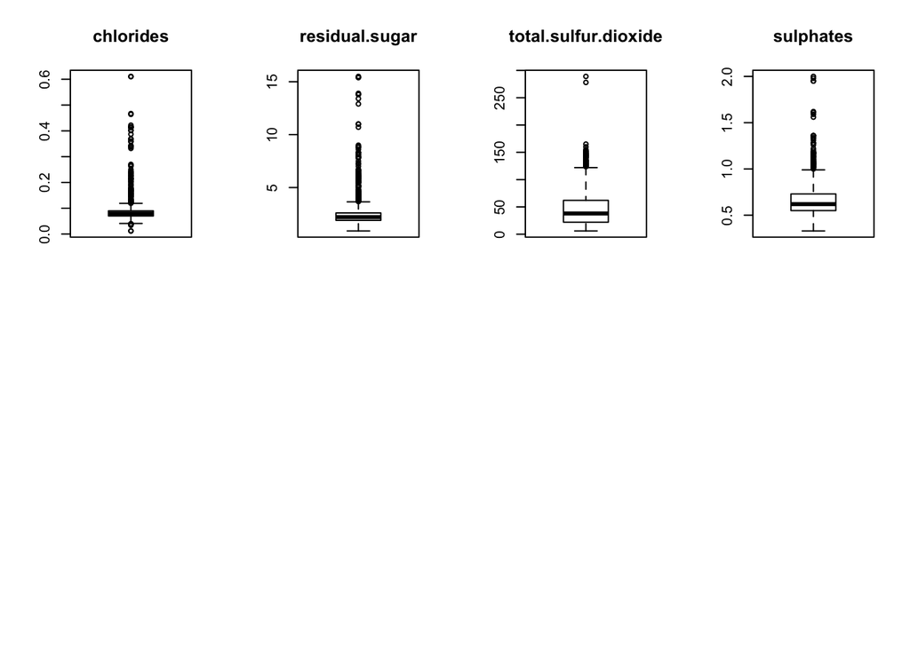

S’observa que, com era d’esperar, hi ha nombrosos *outliers* en aquestes variables. Donat que el total d’outliers suposa el 10% de les dades, es procedeix a eliminar-los per evitar possibles influències negatives en l’anàlisi. S’observa ara que els valors de les variables estan més repartits.

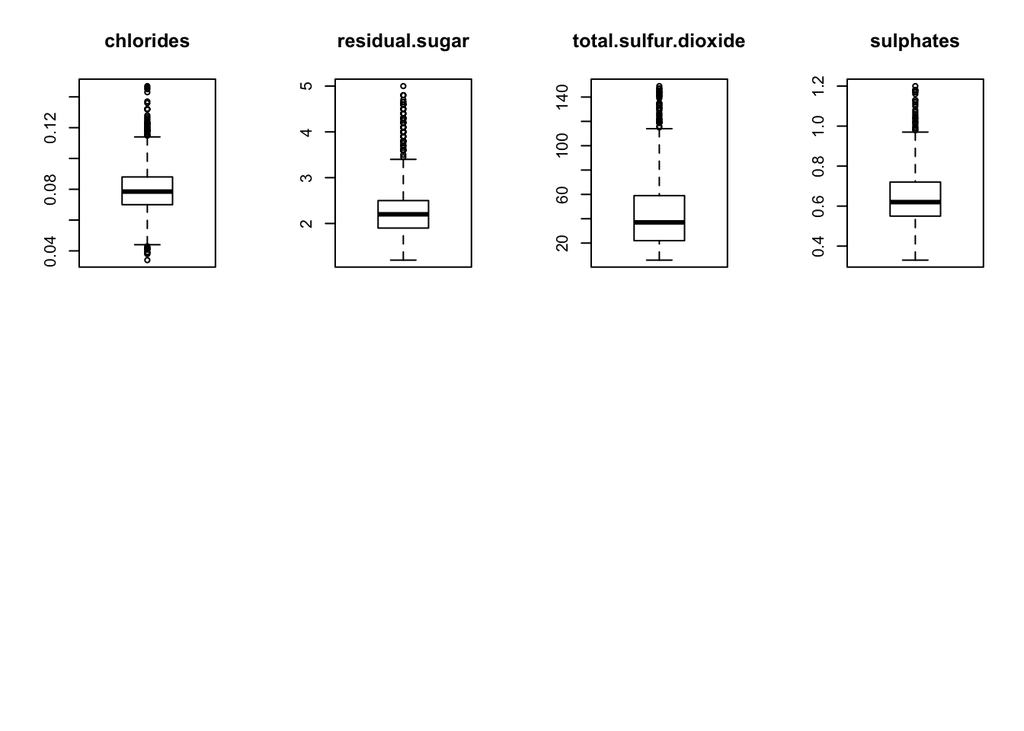

# Anàlisi de Components Principals (PCA)

## Breu síntesi

El primer anàlisi que de les dades que es farà és l’**Anàlisi de Components (PCA)**. Els objectius fonamentals d’aquest estudi són reduir el nombre de variables i realitzar una representació en dues dimensions de les dades (*biplot*). El que es busca són combinacions lineals de les variables de la forma $F_i = a_{i1}X_1 + \cdots + a_{1N}X_pN$ tal que $F_1, \cdots, F_N$ (components principals) no estiguin correlats. Aquestes combinacions lineals ens les dóna la descomposició espectral de la matriu de les dades $F = X A$, on A és la matriu de vectors principals. Una vegada calculats aquests components, ens quedarem amb els suficients per explicar un 80% de la variància de les dades o, en el nostre cas, amb els que tinguin un **valor propi major que 1**.

Una vegada feta aquesta descomposició, es pot fer el *biplot* de les dades a partir de $X = FA$. En aquesta representació, val a dir que les distàncies euclidianes entre els punts aproximen les distàncies Mahalanobis entre les observacions reals. A més, la llargada de les fletxes que representen cada variable és una estimació de la seva desviació estàndard. Ara bé, un dels aspectes més interesants és que l’**angle** entre les diferents fletxes representa una estimació de la correlació entre les dues variables, és a dir:

- Si dues fletxes són gairebé paral·leles i amb el mateix sentit, les variables estaran correlades positivament.
- Si dues fletxes són gairebé paral·leles i amb sentits oposats, les variables estaran correlades negativament.
- Si dues fletxes són gairebé ortogonals, les variables no estaran correlades.

Un altre aspecte a tenir en compte, és si s’utilitza la matriu de covariàncies o la de correlacions pels càlculs. Donat que aquestes dades tenen variables amb unitats de mesura diferents, s’utilitzarà la **matriu de correlacions** (motiu pel qual ens quedarem amb els components principals amb valors propis majors que 1), que és invariant respencte les unitats de mesura.

En resum, els objectius d’aquest anàlisi seràn la representació *biplot* de les dades, la **correlació** entre les variables de la base de dades i els diferents **coeficients** dels components principals més representatius, ja que serà un indicador de les variables més importants.

## PCA de les nostres dades.

Abans de res, es construeix un nou *dataset* eliminant la variable resposta, és a dir, la variable $\texttt{quality}$. Tot seguit, es calcula la matriu de correlacions de les dades, així com el seu *scatter plot* per observar aquestes correlacions.

```
##                      fixed.acidity volatile.acidity   citric.acid
## fixed.acidity            1.0000000     -0.266994660  0.6970263272
## volatile.acidity        -0.2669947      1.000000000 -0.5743546402
## citric.acid              0.6970263     -0.574354640  1.0000000000
## residual.sugar           0.2562919      0.043882659  0.1830280846
## chlorides                0.2599116      0.103766699  0.1316719088
## free.sulfur.dioxide     -0.1629395     -0.021098530 -0.0825786899
## total.sulfur.dioxide    -0.1155196      0.084253502  0.0001528991
## density                  0.6973400     -0.004704452  0.3891438503
## pH                      -0.7144390      0.236975992 -0.5267910623
## sulphates                0.2087144     -0.336055195  0.2913133654
## alcohol                 -0.0766056     -0.183823778  0.1181286119
##                      residual.sugar   chlorides free.sulfur.dioxide
## fixed.acidity            0.25629194  0.25991163         -0.16293946
## volatile.acidity         0.04388266  0.10376670         -0.02109853
## citric.acid              0.18302808  0.13167191         -0.08257869
## residual.sugar           1.00000000  0.25629623          0.02164089
## chlorides                0.25629623  1.00000000         -0.00275134
## free.sulfur.dioxide      0.02164089 -0.00275134          1.00000000
## total.sulfur.dioxide     0.09024186  0.10708125          0.64615172
## density                  0.37713107  0.41602098         -0.06504795
## pH                      -0.12650274 -0.24239591          0.11766371
## sulphates                0.04443907 -0.03004194          0.06341016
## alcohol                  0.11790589 -0.24689180         -0.05470825
##                      total.sulfur.dioxide      density           pH
## fixed.acidity               -0.1155195673  0.697340022 -0.714439012
## volatile.acidity             0.0842535020 -0.004704452  0.236975992
## citric.acid                  0.0001528991  0.389143850 -0.526791062
## residual.sugar               0.0902418632  0.377131068 -0.126502743
## chlorides                    0.1070812526  0.416020977 -0.242395906
## free.sulfur.dioxide          0.6461517202 -0.065047945  0.117663710
## total.sulfur.dioxide         1.0000000000  0.076698681 -0.004352554
## density                      0.0766986812  1.000000000 -0.376163096
## pH                          -0.0043525544 -0.376163096  1.000000000
## sulphates                   -0.0379376697  0.131001431 -0.041190430
## alcohol                     -0.2332413483 -0.505537180  0.207558302
##                        sulphates     alcohol
## fixed.acidity         0.20871441 -0.07660560
## volatile.acidity     -0.33605519 -0.18382378
## citric.acid           0.29131337  0.11812861
## residual.sugar        0.04443907  0.11790589
## chlorides            -0.03004194 -0.24689180
## free.sulfur.dioxide   0.06341016 -0.05470825
## total.sulfur.dioxide -0.03793767 -0.23324135
## density               0.13100143 -0.50553718
## pH                   -0.04119043  0.20755830
## sulphates             1.00000000  0.23540400
## alcohol               0.23540400  1.00000000
```

```
## [1] 24
```

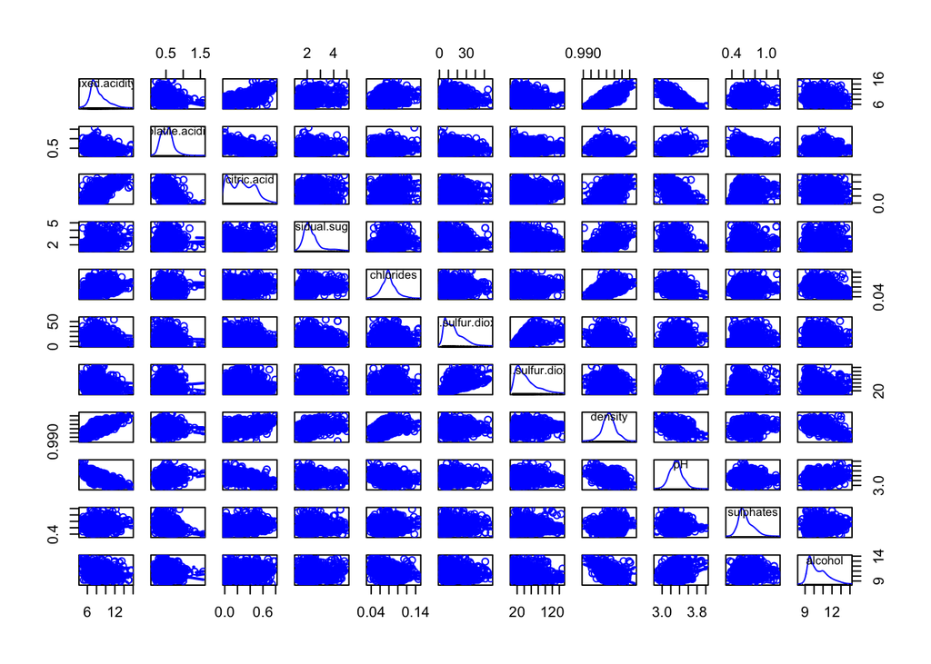

S’observa, tant en la matriu de correlacions com en el plot de les variables que, en general, **no hi ha correlació entre elles**. De fet, la majoria de valors de la matriu de correlació són inferiors a 0.3. Només hi ha 4 casos que cal destacar:

- $\texttt{fixed.acidity}$ i $\texttt{density}$ estan positivament correlades: 0.697.
- $\texttt{fixed.acidity}$ i $\texttt{pH}$ estan negativament correlades: 0.714.
- $\texttt{fixed.acidity}$ i $\texttt{citric.acid}$ estan positivament correlades: 0.697.
- $\texttt{free.sulfur.dioxide}$ i $\texttt{free.sulfur.dioxide}$ estan positivament correlades: 0.646.

Ara bé, en cap d’aquests casos la correlació entre les variables en qüestió és major que 0.75. És a dir, que no són correlacions molt clares. Calculem ara els components principals que s’han explicat a l’apartat anterior.

```
## Importance of components:
##                           Comp.1    Comp.2    Comp.3    Comp.4     Comp.5
## Standard deviation     1.7943537 1.4149643 1.2644268 1.0610261 0.90896784
## Proportion of Variance 0.2927005 0.1820113 0.1453432 0.1023433 0.07511114
## Cumulative Proportion  0.2927005 0.4747118 0.6200550 0.7223983 0.79750940
##                            Comp.6     Comp.7     Comp.8     Comp.9
## Standard deviation     0.82277278 0.75246762 0.62604171 0.59388657
## Proportion of Variance 0.06154137 0.05147341 0.03562984 0.03206375
## Cumulative Proportion  0.85905076 0.91052417 0.94615401 0.97821776
##                          Comp.10     Comp.11
## Standard deviation     0.4263341 0.240507554
## Proportion of Variance 0.0165237 0.005258535
## Cumulative Proportion  0.9947415 1.000000000
```

A continuació es presenta la representació *biplot* corresponent a aquests components principals.

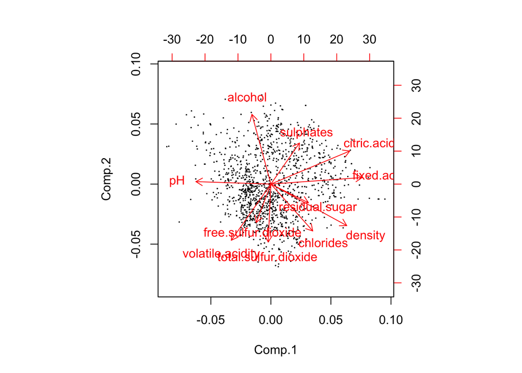

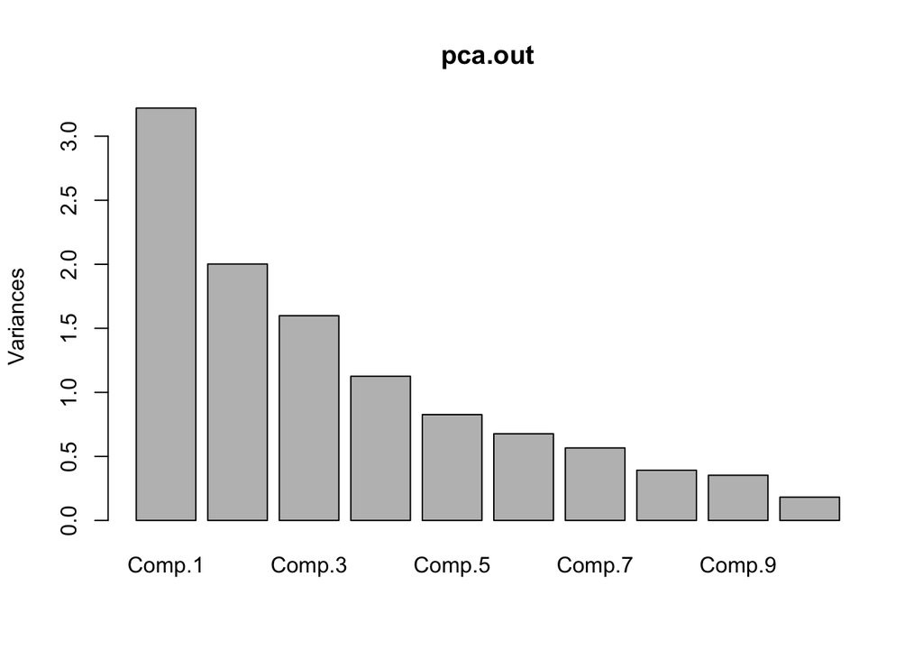

El primer que cal dir d’aquesta representació és que només explica el 47.47% de la variabilitat de les dades, ja que s’hi veuen representats només els dos primers components principals. Així doncs, aquesta representació no és del tot fiable. Alguns fets que ho demostres són que, per exemple, les fletxes de les varaibles $\texttt{residual.sugar}$ i $\texttt{density}$ són pràcticament paral.leles i, en canvi, la correlació entre aquestes dues varaibles és de 0.377. Això podria ser degut a què els 2 primers components principals no representen gaire la variabilitat d’aquestes variables i es centren més en altres.

Tot i així, es veur representada molt representada la correlació negativa de la variable $\texttt{fixed.acidity}$ i $\texttt{pH}$, fet que pot voler dir que tenen gran part de la seva variància explicada pels dos primers components. El mateix passsa amb la correlació positiva de $\texttt{fixed.acidity}$ i $\texttt{citric.acid}$.

A continuació, s’analitzen els coeficients dels components principals, per veure quines variables expliquen més.

```
##
## Loadings:
##                      Comp.1 Comp.2 Comp.3 Comp.4 Comp.5 Comp.6 Comp.7
## fixed.acidity         0.510                              0.161  0.261
## volatile.acidity     -0.221 -0.398  0.311 -0.240         0.198  0.633
## citric.acid           0.440  0.234 -0.183         0.177        -0.124
## residual.sugar        0.210 -0.132        -0.744  0.234  0.271 -0.272
## chlorides             0.234 -0.332  0.112 -0.242 -0.122 -0.863
## free.sulfur.dioxide         -0.272 -0.640                       0.105
## total.sulfur.dioxide        -0.410 -0.549         0.146
## density               0.424 -0.294  0.110        -0.314  0.295 -0.177
## pH                   -0.419               -0.272 -0.351        -0.451
## sulphates             0.160  0.290 -0.316 -0.168 -0.751         0.310
## alcohol              -0.106  0.494 -0.158 -0.461  0.285 -0.155  0.308
##                      Comp.8 Comp.9 Comp.10 Comp.11
## fixed.acidity         0.281  0.210  0.328   0.634
## volatile.acidity      0.244 -0.134 -0.345
## citric.acid           0.397 -0.307 -0.639
## residual.sugar       -0.379        -0.133   0.141
## chlorides
## free.sulfur.dioxide          0.658 -0.226
## total.sulfur.dioxide        -0.616  0.339
## density               0.286  0.104  0.255  -0.587
## pH                    0.556                 0.327
## sulphates            -0.268 -0.132
## alcohol               0.294         0.328  -0.337
##
##                Comp.1 Comp.2 Comp.3 Comp.4 Comp.5 Comp.6 Comp.7 Comp.8
## SS loadings     1.000  1.000  1.000  1.000  1.000  1.000  1.000  1.000
## Proportion Var  0.091  0.091  0.091  0.091  0.091  0.091  0.091  0.091
## Cumulative Var  0.091  0.182  0.273  0.364  0.455  0.545  0.636  0.727
##                Comp.9 Comp.10 Comp.11
## SS loadings     1.000   1.000   1.000
## Proportion Var  0.091   0.091   0.091
## Cumulative Var  0.818   0.909   1.000
```

# Anàlisi Discriminant (LDA/QDA)

## Breu síntesi

En LDA, assumim que les dades de les diferents $k$ classes provenen d’una distribució gaussiana i la seva funció de densitat es pot escriure com:
$$f_k(x) = \frac{1}{\sqrt{2\pi\sigma}} \exp(-\frac{1}{2\sigma^2}(x-\mu_k)^2)$$

on, per cada classe $k$, $\mu_k$ és la mitjana de la classe $k$ i $\sigma$ és la variància comuna de totes les dades (un altre requisit que assumim quan fem LDA).

El mètode assigna cada observació $x$ a la classe la qual $P_k(x)$ sigui major. Per aquesta tasca de maximització podem considerar la tasca equivalent de trobar el màxim prenent el logaritme i aleshores ens queda la funció discriminant que volíem:

$$\delta_k(x) = x\frac{\mu_k}{\sigma^2} - \frac{\mu_k^2}{2\sigma^2} + \log(\pi_k)$$

Com veiem, és una funció lineal en $x$.

En el nostre cas, però, ens interesseran les dades de distribucions Guassianes multivariants. L’equació del discriminant canvia introduïnt-hi notació vectorial:

$$\delta_k(\mathbf{x}) = \mathbf{x}^\top \Sigma^{-1} \vec{\mu_k} - \frac{1}{2}\; \vec{\mu_k}^\top\; \Sigma^{-1}\; \vec{\mu_k} + \log(\vec{\pi_k})$$

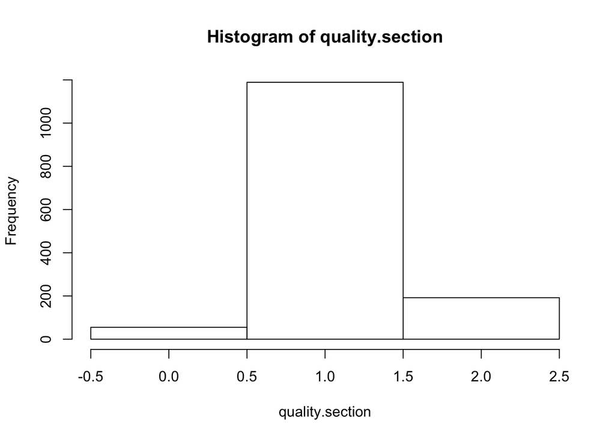

```r
library(MASS)
lda.out <- lda(quality.section ~ X)
lda.out$means
```

```
##   Xfixed.acidity Xvolatile.acidity Xcitric.acid Xresidual.sugar Xchlorides
## 0       7.921818         0.7284545    0.1556364        2.371818 0.08212727
## 1       8.254079         0.5369092    0.2488730        2.272035 0.08014130
## 2       8.792708         0.4038542    0.3676042        2.332292 0.07431250
##   Xfree.sulfur.dioxide Xtotal.sulfur.dioxide  Xdensity      XpH Xsulphates
## 0             12.09091              33.69091 0.9967000 3.398545  0.5736364
## 1             15.94113              46.73003 0.9967708 3.320202  0.6283431
## 2             13.75000              32.08333 0.9958769 3.296146  0.7466146
##   Xalcohol
## 0 10.20545
## 1 10.27869
## 2 11.53238
```

```r
lda.pred <- predict(lda.out)
(lda.confusiontable <- table(quality.section, lda.pred$class))
```

```
##
## quality.section    0    1    2
##               0    7   48    0
##               1   10 1119   60
##               2    0  105   87
```

```r
sum(diag(lda.confusiontable))/sum(lda.confusiontable)
```

```
## [1] 0.8447075
```

Veiem que distingeix perfectament els vins bons dels dolents però entre mediocres i els extrems hi ha més discrepància. Això es deu a la gran predominància de vins mediocres dins les dades, que els ha donat un paper principal i l’anàlisi s’ha centrat a obtenir millors resultats agrupant vins mediocres. Podríem baixar aquest biaix igualant les dades dels tres conjunts mitjançant la reducció de la classe mediocre i fer múltiples models amb les diferents dades.

```
##    0    1    2
##   55 1189  192
```

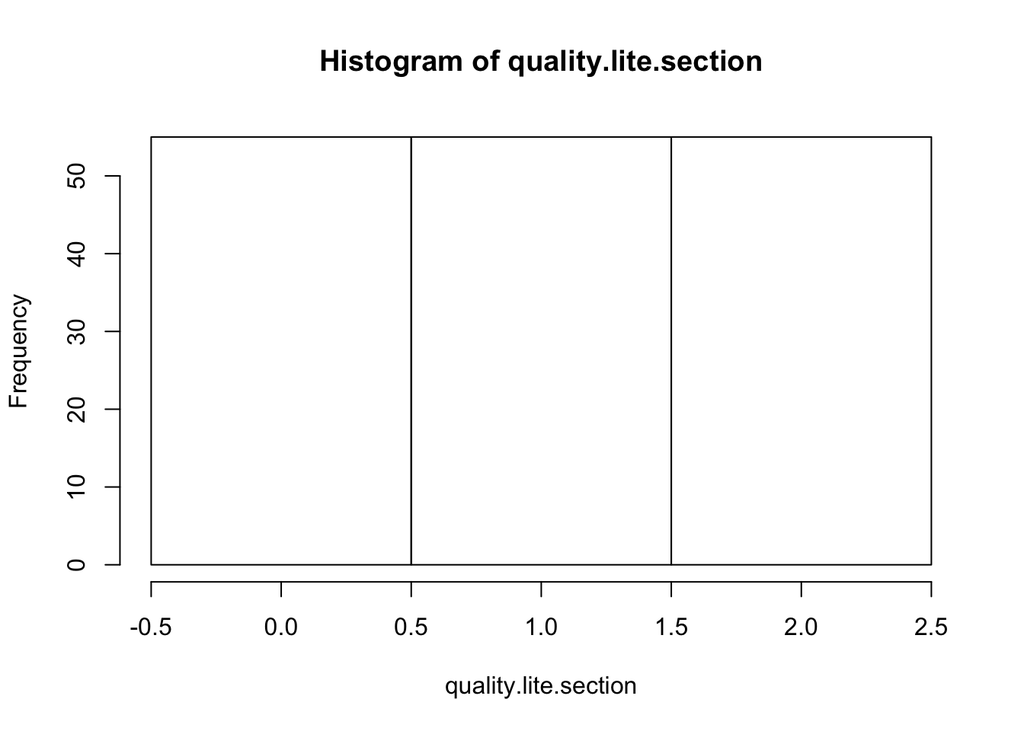

Ara, amb aquesta nova distribució més equitativa de les dades, tornem a fer un LDA.

```r
df.lite <- data.frame(X.lite)
lda.lite.out <- lda(quality.lite.section ~ ., df.lite)
lda.lite.out$means
```

```
##   fixed.acidity volatile.acidity citric.acid residual.sugar  chlorides
## 0      7.921818        0.7284545   0.1556364       2.371818 0.08212727
## 1      8.443636        0.5350000   0.2696364       2.342727 0.08009091
## 2      9.180000        0.3884545   0.3941818       2.228182 0.07232727
##   free.sulfur.dioxide total.sulfur.dioxide   density       pH sulphates
## 0            12.09091             33.69091 0.9967000 3.398545 0.5736364
## 1            16.47273             51.09091 0.9970318 3.318909 0.6538182
## 2            15.74545             36.87273 0.9959500 3.261636 0.7414545
##    alcohol
## 0 10.20545
## 1 10.25000
## 2 11.41485
```

Veiem com ha funcionat ara:

```r
lda.lite.pred <- predict(lda.lite.out)
(lda.lite.confusiontable <- table(quality.lite.section, lda.lite.pred$class))
```

```
##
## quality.lite.section  0  1  2
##                    0 41 13  1
##                    1 11 32 12
##                    2  2  7 46
```

```r
sum(diag(lda.lite.confusiontable))/sum(lda.lite.confusiontable)
```

```
## [1] 0.7212121
```

# Anàlisi clúster

## Breu síntesi

Un altre dels anàlisis que realitzarem sobre les dades és l’**Anàlisi Clúster**, l’anàlisi d’agrupaments. Tal i com indica el seu nom, amb aquest estudi es buscaran els grups naturals que hi ha dins de les dades. Aquests grups estan formats per observacions “semblants” entre elles, on aquest nivell de semblança s’ha de definir prèviament i s’ha d’entendre com la distància entre les observacions. A més, aquest estudi ens permet reduir el conjunt de dades de $n$ observacions a $k$ grups prou semblans.

Pel que fa als algoritmes que s’utilitzen per trobar aquests grups, bàsicament els dividirem en 3 tipus: **jeràrquics**, **no jeràrquics** i els mètodes *model-based*. En relació als primers, val a dir que, un cop una observació s’ha assignat a un grup, ja no canvia de grup. L’algoritme més utilitzat és l’**aglomeració jeràrquica**, que simplement va ajuntant a cada pas les observacions/grups que estiguin a menor distància. Pel càlcul de la distància entre dos grups ja creats, es pot considerar:

- **Single linkage**: La distància entre les observacions més properes entre els dos grups. Sensible als outliers.
- **Complete linkage**: La distància entre les observacions més llunyanes entre els dos grups. Sensible als outliers.
- **Average linkage**: La mitjana de la distància entre les observacions dels dos grups. Menys sensible als outliers.
- **Centroid distance**: Es defineix la distància entre grups com $d_{rs}^2 = \sum_{j=1}^p (\bar{x}_{rj} - \bar{x}_{sj})^2$, on $r$ i $s$ són els dos grups. Menys sensible als outliers.
- **Ward’s criterion**: Es defineix $\Delta = \frac{n_r n_s}{n_r + n_s}d_{rs}^2$ i s’agrupen els dos grups amb $\Delta$ mínim. Menys sensible als outliers.

Per altra banda, en els algoritmes **no jeràrquics**, una observació pot anar canviant de grup a mesura que avança el procediment. L’algoritme més utilitzat en aquest cas és el *K-Means*. La idea és anar calculant pas a pas els centres de cada grup i anar ajustant-los a les dades. Es comença amb un conjunt de centres aleatòri i s’assignen les observacions més properes a cada centre. A cada pas es recalculen els centres i es reassignen les dades. Quan en un pas ja no hi ha més reassignacions, s’acaba. En nombre de grups $K$ és fixat.

Per últim, així com tant els algoritmes jeràrquics o no jeràrquics no feien cap tipus d’assumpció sobre la distribució de les dades, en els mètodes **model-based** s’utilitzen models probabilísics concrets per agrupar les dades. La idea és que s’entenen les dades com un *finite mixture model*

$$g(x|\pi, \theta) = \pi_1f_1(x|\theta_1) + \cdots + \pi_kf_k(x|\theta_k)$$

on les $f_i$ són les distribucions de probabilitat de cada un dels $k$ grups, que normalment es té $f_i$ ~ $N(\mu, \Sigma)$. A partir d’aquesta assumpció, es calculen les probabilitats de que cada observació $x_i$ pertanyi al grup $i$ com

$$\frac{\pi_i f_i(x_j|\theta_i)}{\sum_{i=1}^k \pi_i f_i(x_j|\theta_i)}$$

El procediment en aquests algoritmes probabilístics és estimar el *finite mixture model* amb màxima versemblança, calcular les probabilitats *a-posteriori* de cada observació a cada grup i assignar-la al grup on tingui una probabilitat més elevada.